# Part I - (Ford GoBike System Dataset Exploration)

## Introduction

> _ SECTION 1: IMPORT LIBRARIES AND SETTINGS

```python
# import all packages and set plots to be embedded inline
import numpy as np
import pandas as pd
import matplotlib.pyplot as plt
import seaborn as sb
import datetime as dt
import warnings

%matplotlib inline
```

```python
warnings.filterwarnings('ignore')
```

```python
pd.options.mode.chained_assignment = None  # default='warn'
```

> _ SECTION 2: DEFINE FUNCTIONS

```python
#store different color in variables for later use
dark_blue = sb.color_palette()[0]
orange = sb.color_palette()[1]
green =  sb.color_palette()[2]
red = sb.color_palette()[3]
purple = sb.color_palette()[4]
brown = sb.color_palette()[5]
grey = sb.color_palette()[7]
```

```python
# a func to plot a univariate countplot
def plot_count(dataframe, x_axis= None, y_axis = None, plot_title = None, plot_order = None, plot_color = None,
               tick_rotation = None, plot_fontsize = None, tick_fontsize = 12, x_label = None, y_label = None,
               plot_hue = None, plot_title_fontsize = 18, plot_figsize = (15, 5), bartext_fontsize = 12, show_count = False):
    if plot_hue == None:
    #This is for plotting univariate count plots

        plt.rcParams["figure.figsize"] = list(plot_figsize)
        plt.rcParams["figure.autolayout"] = True
        plt.rcParams['font.size'] = bartext_fontsize
        plot = sb.countplot(data = dataframe, x = x_axis, y = y_axis, order = plot_order, color = plot_color)
        if show_count == True:
            for p in plot.patches:
            #plot.annotate('{:.0f}'.format(p.get_height()), (p.get_x()+0.25, p.get_height()+5))
                plot.text(p.get_x(), p.get_height(), '{:.0f}'.format(p.get_height(), va = 'center', ha = 'center',  fontdict = None,))
        plt.title(plot_title) if plot_title == None else plt.title(plot_title.upper(), fontsize = plot_title_fontsize)
        plt.xticks(fontsize = tick_fontsize, rotation = tick_rotation)
        plt.yticks(fontsize = tick_fontsize)
        plt.xlabel('' if x_label == None else x_label.upper(), fontsize = 12 if plot_fontsize == None else plot_fontsize)
        plt.ylabel('' if y_label == None else y_label.upper(), fontsize = 12 if plot_fontsize == None else plot_fontsize);
        plt.plot()
    else:
        #This would plot bivariate count plots or bar charts
        plt.rcParams["figure.figsize"] = list(plot_figsize)
        plt.rcParams["figure.autolayout"] = True
        plt.rcParams['font.size'] = bartext_fontsize
        plot = sb.countplot(data = dataframe, hue = plot_hue, x = x_axis, y = y_axis, order = plot_order, color = plot_color)
        for p in plot.patches:
            plot.text(p.get_x(), p.get_height(), '{:.0f}'.format(p.get_height(), va = 'center', ha = 'center',  fontdict = None,))
            #plot.annotate('{:.0f}'.format(p.get_height()), (p.get_x()+0.25, p.get_height()+0.01))
        plt.title(plot_title) if plot_title == None else plt.title(plot_title.upper(), fontsize = plot_title_fontsize)
        plt.xticks(rotation = tick_rotation)
        plt.xticks(fontsize = 12 if tick_fontsize == None else tick_fontsize, rotation = tick_rotation)
        plt.yticks(fontsize = 12 if tick_fontsize == None else tick_fontsize)
        plt.xlabel('' if x_label == None else x_label.upper(), fontsize = 12 if plot_fontsize == None else plot_fontsize)
        plt.ylabel('' if y_label == None else y_label.upper(), fontsize = 12 if plot_fontsize == None else plot_fontsize);
        plt.tight_layout()
        plt.plot()
plt.show();
```

```python
# A function to plot a pie chart
def plot_pie(dataframe, column, plot_startangle = 0, plot_counterclock = False, plot_title = None, plot_fontsize = 12,
             plot_title_fontsize = 18, plot_figsize = (8,8)):
    counts = dataframe[column].value_counts()
    label = counts.index
    plt.figure(figsize = plot_figsize);
    plt.pie(counts, startangle = plot_startangle, counterclock = plot_counterclock, autopct='%.3f%%' )
    plt.legend(labels = label, fontsize = plot_fontsize, loc= 'center right', bbox_to_anchor = (1.2, 0.5))
    plt.title('' if plot_title == None else plot_title.upper(), fontsize = plot_title_fontsize)
    plt.axis('square');
```

```python
# define a func to plot hist
def sb_plot_hist(dataframe, x_axis = None, y_axis = None, plot_title = None, plot_title_font_size = 18,
              x_label = None, y_label = None, plot_fontsize = 12, plot_bin_number = 500, plot_color = None,
              tick_fontsize = 12, plot_figsize = (15,10)):
    plt.figure(figsize=plot_figsize)
    plot = sb.histplot(data = dataframe, x = x_axis, bins = plot_bin_number,
                       color = plot_color)
    plt.title('' if plot_title == None else plot_title.upper(), fontsize = plot_title_fontsize)
    plt.xticks(fontsize = tick_fontsize)
    plt.yticks(fontsize =  tick_fontsize)
    plt.xlabel('' if x_label == None else x_label.upper(), fontsize = plot_fontsize)
    plt.ylabel('' if y_label == None else y_label.upper(), fontsize = plot_fontsize);
```

```python
def plt_plot_hist(dataframe, x_axis = None, y_axis = None, bin_num = 1000, plot_title = None, plot_title_font_size = 18,
                 x_label = None, y_label = None, plot_fontsize = 12, plot_color = None, tick_fontsize = 12,
                  plot_figsize = (15,10), bin_edge = 0, axis = [], axis_set = False):
    bin = np.arange(bin_edge, dataframe[y_axis if x_axis == None else x_axis].max()+bin_num, bin_num)
    plt.figure(figsize = plot_figsize)
    plt.hist(data = dataframe, x = x_axis, bins = bin);
    plt.title('' if plot_title == None else plot_title.upper(), fontsize = plot_title_font_size)
    plt.xticks(fontsize = tick_fontsize)
    plt.yticks(fontsize =  tick_fontsize)
    plt.xlabel('' if x_label == None else x_label.upper(), fontsize = plot_fontsize)
    plt.ylabel('' if y_label == None else y_label.upper(), fontsize = plot_fontsize);
    plt.axis(axis) if axis_set == True else []
```

```python
# define a func to plot kernel density estimate
def plot_kde(dataframe, x_axis = None, y_axis = None, plot_title = None, x_label = None, y_label = None,
             should_fill = False, plot_fontsize = None, tick_fontsize = None, plot_figsize =(15,5) ):
    #dataset = sb.load_dataset('dataframe')
    plt.figure(figsize= plot_figsize)
    sb.kdeplot(data = dataframe, x = x_axis, y = y_axis, fill = should_fill)
    plt.title('' if plot_title == None else plot_title.upper(), fontsize = 12 if plot_fontsize == None else plot_fontsize)
    plt.xticks(fontsize = 12 if tick_fontsize == None else tick_fontsize)
    plt.yticks(fontsize = 12 if tick_fontsize == None else tick_fontsize)
    plt.xlabel('' if x_label == None else x_label.upper(), fontsize = 12 if plot_fontsize == None else plot_fontsize)
    plt.ylabel('' if y_label == None else y_label.upper(), fontsize = 12 if plot_fontsize == None else plot_fontsize);
```

```python
def sb_scatter_plot(dataframe, x_axis = None, y_axis = None, plot_title = None, plot_title_font_size = 18, x_label = None,
             y_label = None, plot_fontsize = 12, plot_color = None, tick_fontsize = 12, plot_figsize = (15,10),
#if you want to plot a regplot, you supply the regplot title and regplot = True
                    reg_plot = False, reg_plot_title = None, plot_hue = None, marker = None , alpha = 0.25, cmap = 'cmap'):
    #print(dataframe, x_axis, y_axis)
    #make arrangements to accomodate jitter and transparency
    if plot_hue == None:
        plt.figure(figsize=plot_figsize)
        plot = sb.scatterplot(data = dataframe, x = x_axis, y = y_axis)
        plt.title('' if plot_title == None else plot_title.upper(), fontsize = plot_title_font_size)
        plt.xticks(fontsize = tick_fontsize)
        plt.yticks(fontsize =  tick_fontsize)
        plt.xlabel('' if x_label == None else x_label.upper(), fontsize = plot_fontsize)
        plt.ylabel('' if y_label == None else y_label.upper(), fontsize = plot_fontsize)
        plt.show();
        if reg_plot == True:
            plot = sb.regplot(data = dataframe, x = x_axis, y = y_axis)
            plt.title('' if reg_plot_title == None else reg_plot_title.upper(), fontsize = plot_title_font_size)
            plt.xticks(fontsize = tick_fontsize)
            plt.yticks(fontsize =  tick_fontsize)
            plt.xlabel('' if x_label == None else x_label.upper(), fontsize = plot_fontsize)
            plt.ylabel('' if y_label == None else y_label.upper(), fontsize = plot_fontsize)
            plt.show();
    else:
        plt.figure(figsize=plot_figsize)
        plot = sb.scatterplot(data = dataframe, x = x_axis, y = y_axis, hue = plot_hue, marker = marker,
                              alpha = alpha, cmap = cmap)
        plt.title('' if plot_title == None else plot_title.upper(), fontsize = plot_title_font_size)
        plt.xticks(fontsize = tick_fontsize)
        plt.yticks(fontsize =  tick_fontsize)
        plt.xlabel('' if x_label == None else x_label.upper(), fontsize = plot_fontsize)
        plt.ylabel('' if y_label == None else y_label.upper(), fontsize = plot_fontsize)
        plt.show();
```

```python
def plot_heat_map(dataframe, columns = (), plot_title = None, plot_title_font_size = 18,x_label = None,
                  y_label = None, plot_fontsize = 12, plot_color = None, tick_fontsize = 12, plot_figsize = (15,10)):
    plt.figure(figsize=plot_figsize)
    sb.set()
    dataset = sb.load_dataset(dataframe)
    dataset = dataset.map(pivot, columns)
    sb.heatmap(dataset)
    plt.title('' if plot_title == None else plot_title.upper(), fontsize = plot_title_font_size)
    plt.xticks(fontsize = tick_fontsize)
    plt.yticks(fontsize =  tick_fontsize)
    plt.show();
```

```python
#Violin plots are used to show the relationships between a quantitative and a qualitative variable
# x_axis must be the categorical variable

# sedan_classes = ['Minicompact Cars', 'Subcompact Cars', 'Compact Cars', 'Midsize Cars', 'Large Cars']
# Change the qualitative variable type using this example
# vclasses = pd.api.types.CategoricalDtype(ordered=True, categories=sedan_classes)
# fuel_econ['VClass'] = fuel_econ['VClass'].astype(vclasses);
'''
Make sure to fill out null values before proceeding to plot your visualizations with this function
Plot the categorical variable on the x_axis
'''
def plot_violin(dataframe, x_axis = None, y_axis = None, plot_title = None, plot_title_font_size = 18,
              x_label = None, y_label = None, plot_fontsize = 12, plot_color = None, tick_fontsize = 12,
                     plot_figsize = (15,10), tick_rotation = None, univariate = False, bivariate = False):
#the categorical/qualitative variable must be the x_axis
# we are going to use occupation and estimatedreturn to test this function
#types of occupation
#Prepare the categorical data for analysis by changing the datatype
    if univariate == True:
        plt.figure(figsize=plot_figsize)
        sb.violinplot(data= dataframe, x= x_axis,)
        plt.title('' if plot_title == None else plot_title.upper(), fontsize = plot_title_font_size)
        plt.xticks(fontsize = tick_fontsize, rotation = tick_rotation)
        plt.yticks(fontsize =  tick_fontsize)
        plt.xlabel('' if x_label == None else x_label.upper(), fontsize = plot_fontsize)
        plt.ylabel('' if y_label == None else y_label.upper(), fontsize = plot_fontsize)
        plt.show();
    elif bivariate == True:
        variable_classes = dataframe[x_axis].unique()
        _classes = pd.api.types.CategoricalDtype(ordered = True, categories = variable_classes)
        dataframe[x_axis] = dataframe[x_axis].astype(_classes)
        plt.figure(figsize=plot_figsize)
        sb.violinplot(data= dataframe, x= x_axis, y= y_axis)
        plt.title('' if plot_title == None else plot_title.upper(), fontsize = plot_title_font_size)
        plt.xticks(fontsize = tick_fontsize, rotation = tick_rotation)
        plt.yticks(fontsize =  tick_fontsize)
        plt.xlabel('' if x_label == None else x_label.upper(), fontsize = plot_fontsize)
        plt.ylabel('' if y_label == None else y_label.upper(), fontsize = plot_fontsize)
        plt.show();
    else:
        return('please set univariate = True if you are plotting a single variable or bivariate = True for two variables')
```

```python
# box plots are used to show the relationship between a qualitative and a numerical variable
# x_axis must be the categorical variable
'''
Make sure to fill out null values before proceeding to plot your visualizations with this function
The categorical variable must be assigned to the x_axis
horizontal is used to change the axis of the plot
we can plot univariate box plots by setting the univariate argument to True
'''
def plot_boxplot(dataframe, x_axis= None, y_axis = None, plot_title = None, plot_color = None, tick_rotation = None,
                 plot_fontsize = None, tick_fontsize =12 , x_label = None, y_label = None, plot_figsize =(15,10),
                 horizontal = False, univariate = False, bivariate = False):
    if univariate == True:
        plt.figure(figsize = plot_figsize)
        sb.boxplot(data = dataframe, x = x_axis, color = plot_color)
        plt.title(plot_title) if plot_title == None else plt.title(plot_title.upper(), fontsize = 18 if plot_fontsize == None else plot_fontsize)
        plt.xticks(rotation = tick_rotation)
        plt.xticks(fontsize = 12 if tick_fontsize == None else tick_fontsize)
        plt.yticks(fontsize = 12 if tick_fontsize == None else tick_fontsize)
        plt.xlabel('' if x_label == None else x_label.upper(), fontsize = 12 if plot_fontsize == None else plot_fontsize)
        plt.ylabel('' if y_label == None else y_label.upper(), fontsize = 12 if plot_fontsize == None else plot_fontsize);
        plt.tight_layout()
        plt.show();
    elif bivariate == True:
        #Prepare the categorical data for analysis by changing the datatype
        variable_classes = dataframe[x_axis].unique()
        _classes = pd.api.types.CategoricalDtype(ordered = True, categories = variable_classes)
        dataframe[x_axis] = dataframe[x_axis].astype(_classes)
        if horizontal == True:
                plt.figure(figsize = plot_figsize)
                sb.boxplot(data = dataframe, y = x_axis, x = y_axis, color = plot_color)
                plt.title(plot_title) if plot_title == None else plt.title(plot_title.upper(), fontsize = 18 if plot_fontsize == None else plot_fontsize)
                plt.xticks(rotation = tick_rotation)
                plt.xticks(fontsize = 12 if tick_fontsize == None else tick_fontsize)
                plt.yticks(fontsize = 12 if tick_fontsize == None else tick_fontsize)
                plt.xlabel('' if x_label == None else x_label.upper(), fontsize = 12 if plot_fontsize == None else plot_fontsize)
                plt.ylabel('' if y_label == None else y_label.upper(), fontsize = 12 if plot_fontsize == None else plot_fontsize);
                plt.tight_layout()
                plt.show();
        else:
                plt.figure(figsize = plot_figsize)
                sb.boxplot(data = dataframe, x = x_axis, y = y_axis)
                plt.title(plot_title) if plot_title == None else plt.title(plot_title.upper(), fontsize = 18 if plot_fontsize == None else plot_fontsize)
                plt.xticks(rotation = tick_rotation)
                plt.xticks(fontsize = 12 if tick_fontsize == None else tick_fontsize)
                plt.yticks(fontsize = 12 if tick_fontsize == None else tick_fontsize)
                plt.xlabel('' if x_label == None else x_label.upper(), fontsize = 12 if plot_fontsize == None else plot_fontsize)
                plt.ylabel('' if y_label == None else y_label.upper(), fontsize = 12 if plot_fontsize == None else plot_fontsize);
                plt.tight_layout()
                plt.show();
    else:
        return('Warning! please set univariate = True if you are plotting a single variable or bivariate = True for two variables')
```

```python
def plot_lineplot(dataframe, x_axis = None, y_axis = None, plot_title = None, plot_title_font_size = 18,
              x_label = None, y_label = None, plot_fontsize = 12, plot_color = None, tick_fontsize = 12,
                     plot_figsize = (15,10)):
    plt.figure(figsize=plot_figsize)
    plt.title('' if plot_title == None else plot_title.upper(), fontsize = plot_title_font_size)
    plt.xticks(fontsize = tick_fontsize)
    plt.yticks(fontsize =  tick_fontsize)
    plt.xlabel('' if x_label == None else x_label.upper(), fontsize = plot_fontsize)
    plt.ylabel('' if y_label == None else y_label.upper(), fontsize = plot_fontsize)
    plt.show();
```

```python
def to_categorical_dtype(dataframe, column_names = []):
    for column_name in column_names:
        variable_classes = dataframe[column_name].unique()
        _classes = pd.api.types.CategoricalDtype(ordered = True, categories = variable_classes)
        dataframe[column_name] = dataframe[column_name].astype(_classes)
```

> _ SECTION 3: LOAD IN THE DATASET AND PERFORM SOME ASSESSMENT

```python
#store the dataset in variable df
df = pd.read_csv('201902-fordgobike-tripdata.csv')
```

```python
#make a copy of the dataset
ford = df.copy()
```

```python
# high level programmatic assessment
ford.head()
```

|  | duration_sec | start_time | end_time | start_station_id | start_station_name | start_station_latitude | start_station_longitude | end_station_id | end_station_name | end_station_latitude | end_station_longitude | bike_id | user_type | member_birth_year | member_gender | bike_share_for_all_trip |
| --- | --- | --- | --- | --- | --- | --- | --- | --- | --- | --- | --- | --- | --- | --- | --- | --- |
| 0 | 52185 | 2019-02-28 17:32:10.1450 | 2019-03-01 08:01:55.9750 | 21.0 | Montgomery St BART Station (Market St at 2nd St) | 37.789625 | -122.400811 | 13.0 | Commercial St at Montgomery St | 37.794231 | -122.402923 | 4902 | Customer | 1984.0 | Male | No |
| 1 | 42521 | 2019-02-28 18:53:21.7890 | 2019-03-01 06:42:03.0560 | 23.0 | The Embarcadero at Steuart St | 37.791464 | -122.391034 | 81.0 | Berry St at 4th St | 37.775880 | -122.393170 | 2535 | Customer | NaN | NaN | No |
| 2 | 61854 | 2019-02-28 12:13:13.2180 | 2019-03-01 05:24:08.1460 | 86.0 | Market St at Dolores St | 37.769305 | -122.426826 | 3.0 | Powell St BART Station (Market St at 4th St) | 37.786375 | -122.404904 | 5905 | Customer | 1972.0 | Male | No |
| 3 | 36490 | 2019-02-28 17:54:26.0100 | 2019-03-01 04:02:36.8420 | 375.0 | Grove St at Masonic Ave | 37.774836 | -122.446546 | 70.0 | Central Ave at Fell St | 37.773311 | -122.444293 | 6638 | Subscriber | 1989.0 | Other | No |
| 4 | 1585 | 2019-02-28 23:54:18.5490 | 2019-03-01 00:20:44.0740 | 7.0 | Frank H Ogawa Plaza | 37.804562 | -122.271738 | 222.0 | 10th Ave at E 15th St | 37.792714 | -122.248780 | 4898 | Subscriber | 1974.0 | Male | Yes |

```python
# high level programmatic assessment
ford.tail()
```

|  | duration_sec | start_time | end_time | start_station_id | start_station_name | start_station_latitude | start_station_longitude | end_station_id | end_station_name | end_station_latitude | end_station_longitude | bike_id | user_type | member_birth_year | member_gender | bike_share_for_all_trip |
| --- | --- | --- | --- | --- | --- | --- | --- | --- | --- | --- | --- | --- | --- | --- | --- | --- |
| 183407 | 480 | 2019-02-01 00:04:49.7240 | 2019-02-01 00:12:50.0340 | 27.0 | Beale St at Harrison St | 37.788059 | -122.391865 | 324.0 | Union Square (Powell St at Post St) | 37.788300 | -122.408531 | 4832 | Subscriber | 1996.0 | Male | No |
| 183408 | 313 | 2019-02-01 00:05:34.7440 | 2019-02-01 00:10:48.5020 | 21.0 | Montgomery St BART Station (Market St at 2nd St) | 37.789625 | -122.400811 | 66.0 | 3rd St at Townsend St | 37.778742 | -122.392741 | 4960 | Subscriber | 1984.0 | Male | No |
| 183409 | 141 | 2019-02-01 00:06:05.5490 | 2019-02-01 00:08:27.2200 | 278.0 | The Alameda at Bush St | 37.331932 | -121.904888 | 277.0 | Morrison Ave at Julian St | 37.333658 | -121.908586 | 3824 | Subscriber | 1990.0 | Male | Yes |
| 183410 | 139 | 2019-02-01 00:05:34.3600 | 2019-02-01 00:07:54.2870 | 220.0 | San Pablo Ave at MLK Jr Way | 37.811351 | -122.273422 | 216.0 | San Pablo Ave at 27th St | 37.817827 | -122.275698 | 5095 | Subscriber | 1988.0 | Male | No |
| 183411 | 271 | 2019-02-01 00:00:20.6360 | 2019-02-01 00:04:52.0580 | 24.0 | Spear St at Folsom St | 37.789677 | -122.390428 | 37.0 | 2nd St at Folsom St | 37.785000 | -122.395936 | 1057 | Subscriber | 1989.0 | Male | No |

```python
# high level programmatic assessment
ford.shape
```

```
(183412, 16)
```

```python
# high level programmatic assessment
ford.describe()
```

|  | duration_sec | start_station_id | start_station_latitude | start_station_longitude | end_station_id | end_station_latitude | end_station_longitude | bike_id | member_birth_year |
| --- | --- | --- | --- | --- | --- | --- | --- | --- | --- |
| count | 183412.000000 | 183215.000000 | 183412.000000 | 183412.000000 | 183215.000000 | 183412.000000 | 183412.000000 | 183412.000000 | 175147.000000 |
| mean | 726.078435 | 138.590427 | 37.771223 | -122.352664 | 136.249123 | 37.771427 | -122.352250 | 4472.906375 | 1984.806437 |
| std | 1794.389780 | 111.778864 | 0.099581 | 0.117097 | 111.515131 | 0.099490 | 0.116673 | 1664.383394 | 10.116689 |
| min | 61.000000 | 3.000000 | 37.317298 | -122.453704 | 3.000000 | 37.317298 | -122.453704 | 11.000000 | 1878.000000 |
| 25% | 325.000000 | 47.000000 | 37.770083 | -122.412408 | 44.000000 | 37.770407 | -122.411726 | 3777.000000 | 1980.000000 |
| 50% | 514.000000 | 104.000000 | 37.780760 | -122.398285 | 100.000000 | 37.781010 | -122.398279 | 4958.000000 | 1987.000000 |
| 75% | 796.000000 | 239.000000 | 37.797280 | -122.286533 | 235.000000 | 37.797320 | -122.288045 | 5502.000000 | 1992.000000 |
| max | 85444.000000 | 398.000000 | 37.880222 | -121.874119 | 398.000000 | 37.880222 | -121.874119 | 6645.000000 | 2001.000000 |

Bike rides in the area usually lasts for a mean time of 726 seconds i.e an average of 12 minutes ± 30minutes as indicated by the standard deviation. The lowest recorded time taken for a bike ride was 61 seconds or approximately 1 minute. At the 75th percentile however, bike rides generally last for 796 seconds or 13minutes and 16 seconds

```python
# high level programmatic assessment
ford.info()
```

```
<class 'pandas.core.frame.DataFrame'>
RangeIndex: 183412 entries, 0 to 183411
Data columns (total 16 columns):
 #   Column                   Non-Null Count   Dtype
---  ------                   --------------   -----
 0   duration_sec             183412 non-null  int64
 1   start_time               183412 non-null  object
 2   end_time                 183412 non-null  object
 3   start_station_id         183215 non-null  float64
 4   start_station_name       183215 non-null  object
 5   start_station_latitude   183412 non-null  float64
 6   start_station_longitude  183412 non-null  float64
 7   end_station_id           183215 non-null  float64
 8   end_station_name         183215 non-null  object
 9   end_station_latitude     183412 non-null  float64
 10  end_station_longitude    183412 non-null  float64
 11  bike_id                  183412 non-null  int64
 12  user_type                183412 non-null  object
 13  member_birth_year        175147 non-null  float64
 14  member_gender            175147 non-null  object
 15  bike_share_for_all_trip  183412 non-null  object
dtypes: float64(7), int64(2), object(7)
memory usage: 22.4+ MB
```

```python
# high level programmatic assessment
ford.duplicated().sum()
```

```
0
```

```python
# high level programmatic assessment
ford.isnull().sum()
```

```
duration_sec                  0
start_time                    0
end_time                      0
start_station_id            197
start_station_name          197
start_station_latitude        0
start_station_longitude       0
end_station_id              197
end_station_name            197
end_station_latitude          0
end_station_longitude         0
bike_id                       0
user_type                     0
member_birth_year          8265
member_gender              8265
bike_share_for_all_trip       0
dtype: int64
```

> _ SECTION 4: Cleaning and Data Transformation

```python
#drop null values total of 197 start_station_id, 197 start_station_name, 197 end_station_id, 197 end_station_name,
#8265 member_birth_year, 8265 member gender
ford.dropna(axis = 0, inplace = True)
```

```python
#reset index after droping null values
ford.reset_index(drop=True, inplace=True)
```

```python
ford.shape
```

```
(174952, 16)
```

```python
#convert the start and end time columns to datetime datatype
ford['start_time'] = pd.to_datetime(ford['start_time'])
ford['end_time'] = pd.to_datetime(ford['end_time'])
```

```python
ford['year'] = ford['end_time'].dt.year
```

```python
#extract the month from the start and end time columns
ford['start_month'] = ford['start_time'].dt.month_name()
```

```python
#extract the month from the start and end time columns
ford['end_month'] = ford['end_time'].dt.month_name()
```

```python
#Extract the days of the week from the start and end time columns
ford['start_day_of_the_week'] = ford['start_time'].dt.day_name()
```

```python
ford['end_day_of_the_week'] = ford['end_time'].dt.day_name()
```

```python
ford['start_date'] = ford['start_time'].dt.date
```

```python
ford['end_date'] = ford['end_time'].dt.date
```

```python
ford['start_time'] = ford['start_time'].dt.time
```

```python
ford['end_time'] = ford['end_time'].dt.time
```

```python
ford['duration_in_hour'] = np.nan
```

```python
y = 0
while y < len(ford['duration_in_hour']):
    secs = int(ford['duration_sec'][y])
    ford['duration_in_hour'][y] = str(dt.timedelta(seconds = secs))
    y += 1
```

```python
pd.set_option('display.max_rows', None, 'display.max_columns', None)
```

```python
ford.tail(100)
```

[output not shown]

[output cut: 70 more lines]

> SECTION 5: REPORT

### What is the structure of your dataset?

> This data set has a total of 183412 entries about 16 variables concerning bike rides in the san franscisco bay area.

### What features in the dataset do you think will help support your investigation into your feature(s) of interest?

> SECTION 6: EXPLORATORY DATA ANALYSIS

#### Univariate Exploration

> QUESTION: WHAT IS THE DISTRIBUTION OF TIME DURATION IN SECONDS

> VISUALIZATION

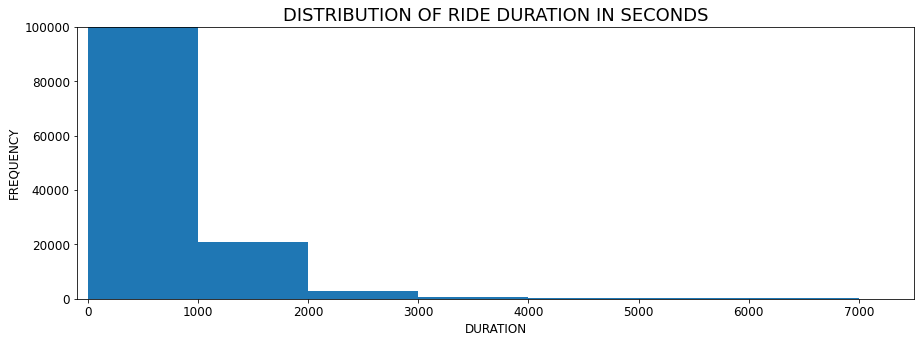

```python
plt_plot_hist(ford, x_axis = 'duration_sec', plot_title = 'distribution of ride duration in seconds', x_label = 'duration',
             y_label = 'frequency', plot_figsize = (15,5), axis = [-100, 7500, 0, 100000], axis_set = True,)
```

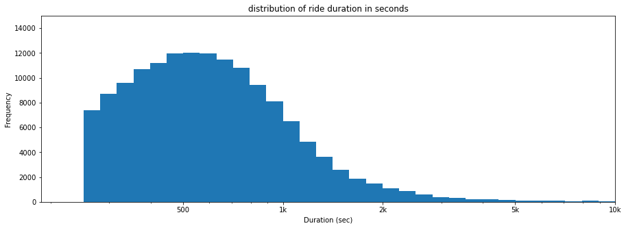

```python
log_binsize = 0.05
log_bins = 10 ** np.arange(2.4, np.log10(df['duration_sec'].max()) + log_binsize, log_binsize)

plt.figure(figsize=(15, 5))
plt.hist(data = ford, x = 'duration_sec', bins = log_bins)
plt.title('distribution of ride duration in seconds')
plt.xlabel('Duration (sec)')
plt.ylabel('Frequency')
plt.xscale('log')
plt.xticks([500, 1e3, 2e3, 5e3, 1e4], [500, '1k', '2k', '5k', '10k'])
plt.axis([-500, 10000, 0, 15000])
plt.show()
```

> OBSERVATION

> QUESTION: WHICH DAYS HAVE THE MOST RIDES OCCURED

> VISUALIZATION

```python
ford['start_day_of_the_week'].unique()
```

```
array(['Thursday', 'Wednesday', 'Tuesday', 'Monday', 'Sunday', 'Saturday',
       'Friday'], dtype=object)
```

```python
to_categorical_dtype(ford, ['start_day_of_the_week'])
```

```python
day_count = ford['start_day_of_the_week'].value_counts()
day_order = day_count.index
```

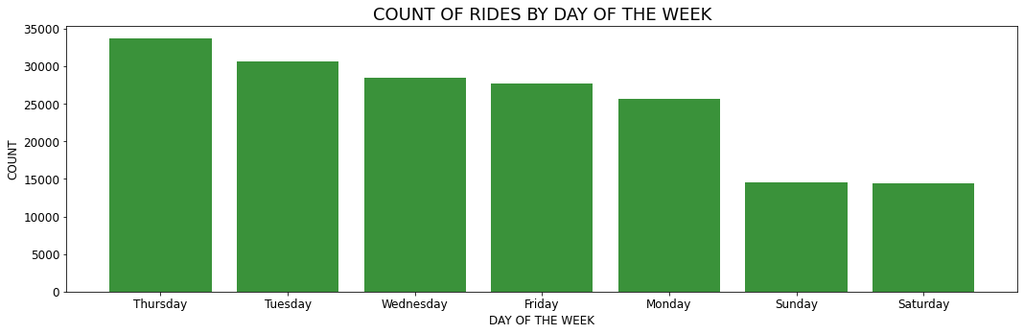

```python
plot_count(ford, x_axis = 'start_day_of_the_week', plot_order = day_order, plot_title ='count of rides by day of the week',
          x_label = 'Day of the week', y_label = 'count', plot_color = green)
```

> QUESTION WHAT AGE GROUP USES THE BIKE RIDE SHARING SYSTEM THE MOST

> VISUALIZATION

```python
# calculate the age of bike riders by subtracting the member birth year from the current year
ford['member_birth_year'] = ford['member_birth_year'].astype('int')
ford['age'] = dt.datetime.now().year - ford['member_birth_year']
```

```python
x = 0
ford['age_category'] = np.nan
age_category = ['child', 'teen','youth', 'adult', 'senior']
while x < len(ford['age']):
    if ford['age'][x] <= 12:
        ford['age_category'][x] = age_category[0]
    elif 12 < ford['age'][x] <= 19:
        ford['age_category'][x] = age_category[1]
    elif 19 < ford['age'][x] <= 40:
        ford['age_category'][x] = age_category[2]
    elif 18 < ford['age'][x] < 60:
        ford['age_category'][x] = age_category[3]
    else:
        ford['age_category'][x] = age_category[4]
    x += 1
```

```python
to_categorical_dtype(ford, ['age_category'])
```

```python
age_category_order = ford['age_category'].value_counts().index
```

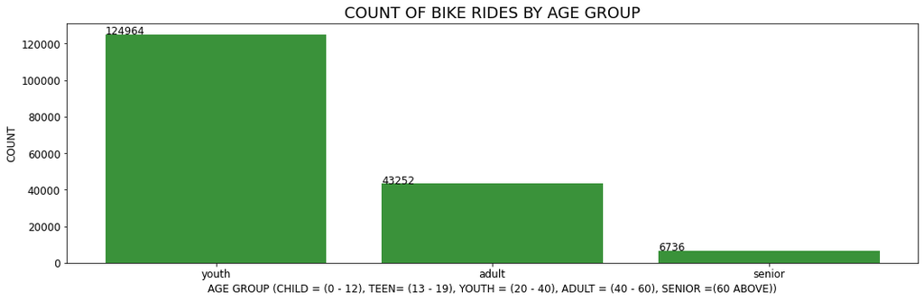

```python
plot_count(ford, x_axis ='age_category', plot_order = age_category_order, show_count = True, y_label = 'count',
           x_label = 'Age group (child = (0 - 12), teen= (13 - 19), youth = (20 - 40), adult = (40 - 60), senior =(60 above))',
           plot_title = 'count of bike rides by age group', plot_color = green)
```

```python
age_count = ford['age'].value_counts()
age_ordered = age_count.index
```

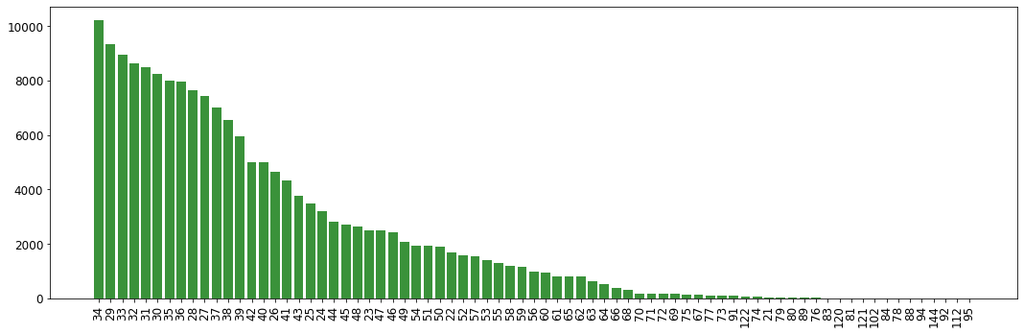

```python
plot_count(ford, 'age', plot_order = age_ordered, plot_color = green, tick_rotation = 90)
```

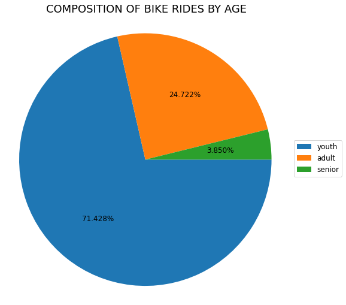

```python
plot_pie(ford, 'age_category', plot_title = 'composition of bike rides by age')
```

> OBSERVATION Bike rides are mostly common for those between age 20 and 40, there are no children or teenagers

> QUESTION: WHAT IS THE DISTRIBUTION OF AGE

> VISUALIZATION

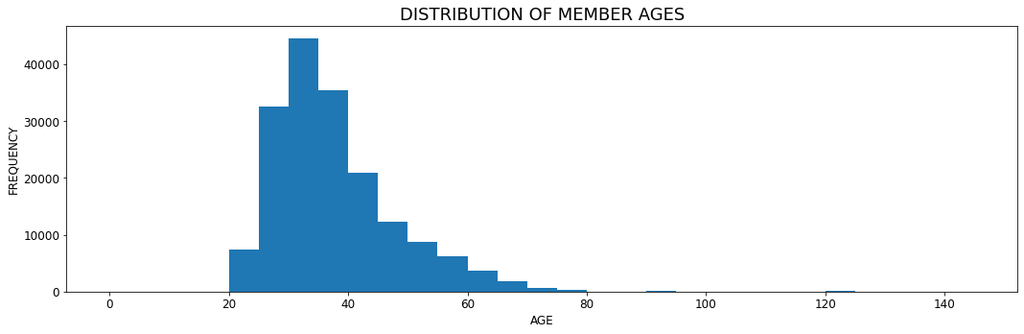

```python
plt_plot_hist(ford, x_axis = 'age', bin_num = 5, plot_title = 'distribution of member ages',
              x_label = 'age', y_label = 'frequency', plot_figsize = (15,5))
```

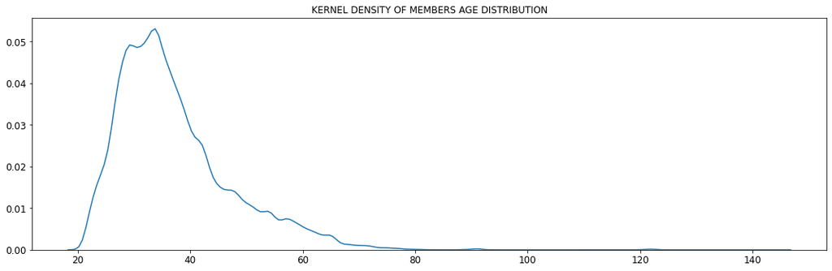

```python
plot_kde(ford, x_axis = 'age', plot_title = 'kernel density of members age distribution', plot_figsize = (15,5))
```

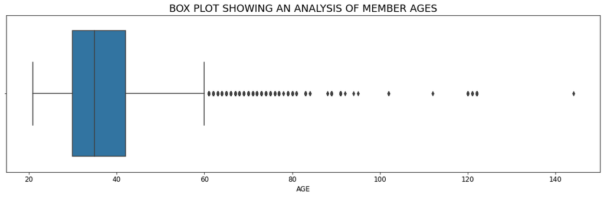

```python
plot_boxplot(ford, x_axis = 'age', univariate = True, plot_title = 'box plot showing an analysis of member ages',
             x_label = 'age', plot_figsize = (15,5))
```

> OBSERVATION The distribution indicates the presence of outliers. members range between the ages of 20 to 80 with the most active users falling between the range of ages 30 and 40 lets see this more clearly using a boxplot

lastly for univariate exploration, let us take a look at bike rides based on user type

> QUESTION:

> VISUALIZATION:

```python
user_type_count = ford['user_type'].value_counts()
user_type_ordered = user_type_count.index
```

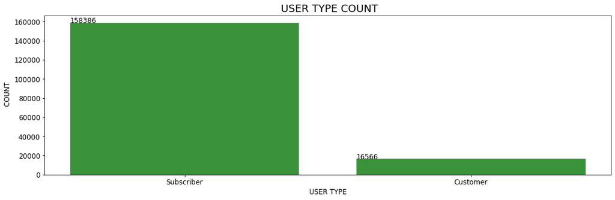

```python
plot_count(ford, x_axis = 'user_type', plot_color = green, show_count = True, plot_title = ' user type count',
           x_label = 'user type', y_label = " count", plot_order = user_type_ordered)
```

```python
user_type_count = ford['member_gender'].value_counts()
user_type_ordered = user_type_count.index
```

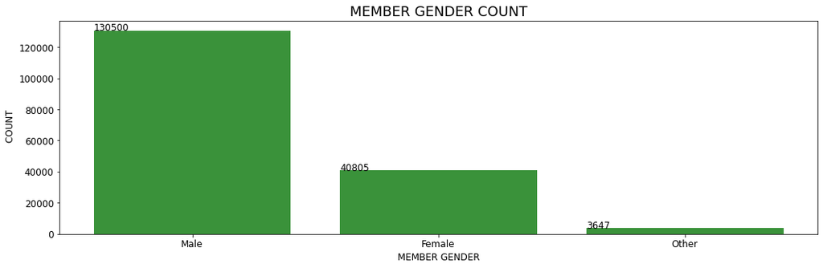

```python
plot_count(ford, x_axis = 'member_gender', plot_color = green, show_count = True, plot_title = 'member gender count',
           x_label = 'member gender', y_label = " count", plot_order = user_type_ordered)
```

```python
ford.head(3)
```

|  | duration_sec | start_time | end_time | start_station_id | start_station_name | start_station_latitude | start_station_longitude | end_station_id | end_station_name | end_station_latitude | end_station_longitude | bike_id | user_type | member_birth_year | member_gender | bike_share_for_all_trip | year | start_month | end_month | start_day_of_the_week | end_day_of_the_week | start_date | end_date | duration_in_hour | age | age_category |
| --- | --- | --- | --- | --- | --- | --- | --- | --- | --- | --- | --- | --- | --- | --- | --- | --- | --- | --- | --- | --- | --- | --- | --- | --- | --- | --- |
| 0 | 52185 | 17:32:10.145000 | 08:01:55.975000 | 21.0 | Montgomery St BART Station (Market St at 2nd St) | 37.789625 | -122.400811 | 13.0 | Commercial St at Montgomery St | 37.794231 | -122.402923 | 4902 | Customer | 1984 | Male | No | 2019 | February | March | Thursday | Friday | 2019-02-28 | 2019-03-01 | 14:29:45 | 38 | youth |
| 1 | 61854 | 12:13:13.218000 | 05:24:08.146000 | 86.0 | Market St at Dolores St | 37.769305 | -122.426826 | 3.0 | Powell St BART Station (Market St at 4th St) | 37.786375 | -122.404904 | 5905 | Customer | 1972 | Male | No | 2019 | February | March | Thursday | Friday | 2019-02-28 | 2019-03-01 | 17:10:54 | 50 | adult |
| 2 | 36490 | 17:54:26.010000 | 04:02:36.842000 | 375.0 | Grove St at Masonic Ave | 37.774836 | -122.446546 | 70.0 | Central Ave at Fell St | 37.773311 | -122.444293 | 6638 | Subscriber | 1989 | Other | No | 2019 | February | March | Thursday | Friday | 2019-02-28 | 2019-03-01 | 10:08:10 | 33 | youth |

> OBSERVATION: of the two user type available, subscribers make the most use of the bike ride sharing system also, males folks use the ride sharing system more than other gender

### Discuss the distribution(s) of your variable(s) of interest. Were there any unusual points? Did you need to perform any transformations?

> Trip duration in seconds had to be analyzed using a log-scale because most of the values fell within the first bin even though there was some distribution. start_time, end_time, start_month, end_month, start_day_of_the_week, end_day_of_the_week, start_date, end_date, duration_in_hour, age, and age_category had to be extracted from the original dataset there by increasing the features from 16

### Of the features you investigated, were there any unusual distributions? Did you perform any operations on the data to tidy, adjust, or change the form of the data? If so, why did you do this?

> age distribution had a lot of outliers

#### Bivariate Exploration

> QUESTION: What is the relationship between bike ride duration and age

> VISUALIZTION:

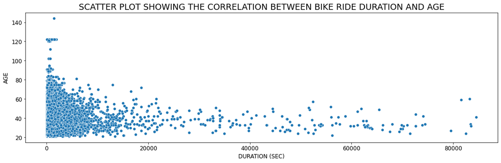

```python
sb_scatter_plot(ford, x_axis = 'duration_sec', y_axis = 'age', plot_figsize =(15,5), x_label = 'Duration (sec)',
               y_label = 'age', plot_title = 'scatter plot showing the correlation between bike ride duration and age')
```

> OBSERVATION: Older people tend to take shorter rides. the longest rides are mostly taken by youths and a few adults. The correlation is negative. From this finding I may suggest that bike sharing companies should target young male populations from between the ages of 20 and 50 for subscription to their service.

> QUESTION: Which gender takes the longest trips

> VISUALIZATION:

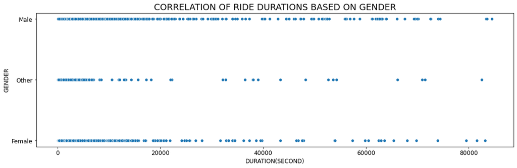

```python
sb_scatter_plot(ford, x_axis = 'duration_sec' , y_axis = 'member_gender', plot_figsize = (15,5), x_label = 'duration(second)',
               y_label = 'gender', plot_title = 'correlation of ride durations based on gender')
```

judging from the density and frequency of points in the correlation chart, I reach the conclusion that

1. more males use the system than other gender
2. bik rides exceeding 40000 secs are mostly taken by males

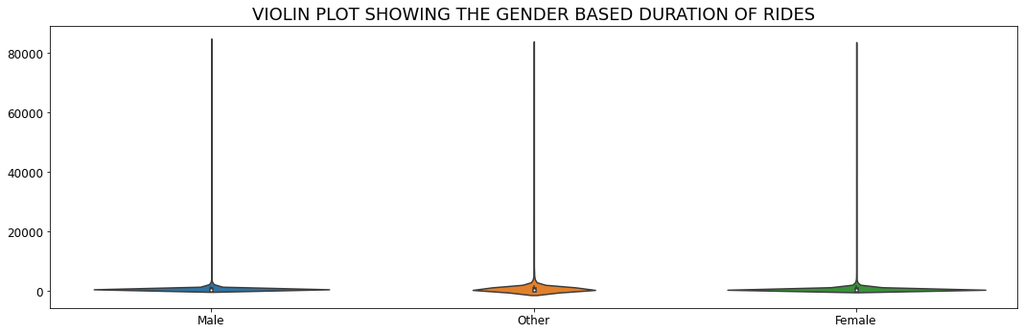

```python
plot_violin(ford, x_axis = 'member_gender', y_axis = 'duration_sec', bivariate = True,
            plot_title = 'violin plot showing the gender based duration of rides', plot_figsize =(15,5))
```

### Did you observe any interesting relationships between the other features (not the main feature(s) of interest)?

#### Multivariate Exploration

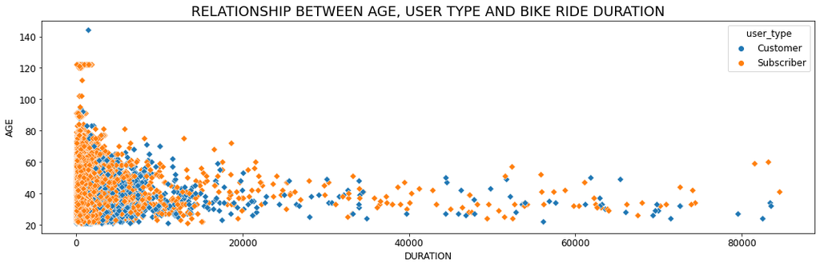

```python
sb_scatter_plot(ford, x_axis = 'duration_sec', y_axis = 'age', plot_hue = 'user_type', alpha = 1, marker ='D',
                plot_title ='relationship between age, user type and bike ride duration', x_label ='Duration', y_label ='age',
               plot_figsize =(15,5))
```

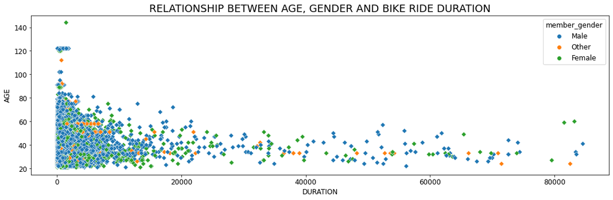

```python
sb_scatter_plot(ford, x_axis = 'duration_sec', y_axis = 'age', plot_hue = 'member_gender', alpha = 1, marker ='D',
                plot_title ='relationship between age, gender and bike ride duration', x_label ='Duration', y_label ='age',
               plot_figsize =(15,5))
```

### Were there any interesting or surprising interactions between features?

outliers were still present in this distribution

#### Conclusions

```python
ford.to_csv('ford_bike_clean.csv', index = False, encoding='utf-8')
```